# Bray Balanced Dissimilarity Surface Temperature & Fishing Interactions for All Regions

Here we will link temperature and fishing to dissimilarity

- This project is a collaborative effort to describe changes in taxonomic composition of fish communities around the world–as sampled by bottom trawl surveys.
- Code by Zoë J. Kitchel

##Here, we examine surface temperature and fishing pressure to predict annual BC balanced dissimilarity for all survey units

```r
library(data.table)
library(ggplot2)
library(lme4)
library(lmerTest)
library(MuMIn)


OISST_data_temp_avgs_full <- readRDS(here::here("data","Temperature","OISST_data_temp_avgs_full.rds"))

OISST_data_temp_avgs_full[,year := year_for_avg]


#pull in average distance decay values
distances_dissimilarities_allyears.r <- readRDS(here::here("output","distance_decay","distances_dissimilarities_allyears.r.rds"))

#pull in fishing data
SAU_summed_tonnes.r <- readRDS(here::here("data","sea_around_us","SAU_summed_tonnes.rds"))

#pull in regional statistics
region_stats <- readRDS(here::here("output","region_stats", "region_stats.rds"))
```

Put into one data table

```r
#temp
distances_dissimilarities_allyears.r.temp <- OISST_data_temp_avgs_full[distances_dissimilarities_allyears.r, on = c("year","survey_unit")]

#fishing
dissimilarities_temp_fishing <- SAU_summed_tonnes.r[distances_dissimilarities_allyears.r.temp, on = c("year", "survey_unit")]

#region_statistics
dissimilarities_temp_fishing_regstats <- dissimilarities_temp_fishing[region_stats, on = "survey_unit"]
dissimilarities_temp_fishing_regstats[,spp_num.s := scale(spp_num)]

dissimilarities_temp_fishing_regstats[,bray_curtis_dissimilarity_balanced_mean.s := scale(bray_curtis_dissimilarity_balanced_mean, center = F),survey_unit]

#save avg values
saveRDS(dissimilarities_temp_fishing_regstats, here::here("output","distance_decay","dissimilarities_temp_fishing_regstats.rds"))
```

Color pallete for survey units

```r
pal_37 <- c(
  "#5A5156", #AI
  "#F6222E", #CHL
  "#F8A19F", #DFO-NF
  "#16FF32", #DFO-QCS
  "#DF00DB", #BITS-1
  "#DB8EDA", #BITS-4
  "#325A9B", #EBS
  "#3283FE", #EVHOE
  "#FEAF16", #FR-CGFS
  "#1C8356", #GMEX-Summer
  "#C4451C", #GOA
  "#85660D", #GRL-DE
  "#B0009F", #GSL-N
  "#BF79B8", #GSL-S
  "#1CBE4F", #ICE-GFS
  "#782AB6", #IE-IGFS
  "#90AD1C", #MEDITS
  "#6B003A", #NAM
  "#A75B00", #NEUS-Fall
  "#E3B072", #NEUS-Spring
  "#02E8B6", #NIGFS-1
  "#97E7D5", #NIGFS-4
  "#B00068", #Nor-BTS-3
  "#00B9E3", #NS-IBTS-1
  "#95E2F4", #NS-IBTS-3
  "#B3CE73", #NZ-CHAT
  "#689500", #NZ-ECSI
  "#AAF400", #NZ-WCSI
  "#AA0DFE", #PT-IBTS
  "#FA0087", #S-GEORG
  "#DEA0FD", #SCS-Summer
  "#FCEF88", #SEUS-fall
  "#A59405", #SEUS-spring
  "#FCE100", #SEUS-summer
  "#C075A6", #WCANN
  "#BDCDFF", #ZAF-ATL
  "#003EFF")  #ZAF-IND
```

Table that will be populated with model results

```r
#depth, scaled, temp var, coefficient, p-value, marg_r^2, cond_r^2, AICc
balanced_dissimilarity_sst_fishing_model_results <- data.table(Depth = as.character(),
                                                       Scaled = as.character(),
                                                       `Temp variable` = as.character(),
                                                       `Fishing`= as.character(),
                                                       `Temp fishing interaction` = as.character(),
                                                       `Mixed effect` = as.character(),
                                                       Intercept = as.numeric(),
                                                       `Temp coefficient` = as.numeric(),
                                                       `Coefficient p-value 1` = as.numeric(),
                                                       `Fishing coefficient` = as.numeric(),
                                                       `Coefficient p-value 2` = as.numeric(),
                                                       `Temp*fishing coefficient` = as.numeric(),
                                                       `Coefficient p-value 3` = as.numeric(),
                                                       `Marginal R-squared` = as.numeric(),
                                                       `Conditional R-squared` = as.numeric(),
                                                       AICc = as.numeric(),
                                                       `Degrees of freedom`=as.numeric())
```

###How well does fishing alone predict mean annual BC balanced dissimilarity?

```r
#random slope and intercept for survey
allreg_dissimilarity_fishing_mean_mod <- lmer(bray_curtis_dissimilarity_balanced_mean ~ summed_tonnes_scaled_byreg + (1 + summed_tonnes_scaled_byreg|survey_unit), data = dissimilarities_temp_fishing_regstats)

coefs <- data.frame(coef(summary(allreg_dissimilarity_fishing_mean_mod)))

balanced_dissimilarity_sst_fishing_model_results_row <- data.table(matrix(c(NA, #depth
                                                            NA, #scaled
                                                            NA, #temp var
                                                            T, #fishing
                                                            NA, #temp fishing interaction
                                                            "survey_slope_intercept", #mixed effect
                                                            round(coefs[1,1],3), #intercept
                                                            NA,#temp coef
                                                            NA,#coef p value
                                                            round(coefs[2,1],3),#fishing coef
                                                            round(coefs[2,5],3),#coef p value
                                                            NA, #interact coef
                                                            NA, #coef p value
                                                round(r.squaredGLMM(allreg_dissimilarity_fishing_mean_mod)[[1]],3), #marginal r squared
                                                round(r.squaredGLMM(allreg_dissimilarity_fishing_mean_mod)[[2]],3), #conditional r-squared
                                                            round(AICc(allreg_dissimilarity_fishing_mean_mod),3),#AICc
                                                            6 #degrees of freedom
                                                            ),nrow =1))

balanced_dissimilarity_sst_fishing_model_results <- rbind(balanced_dissimilarity_sst_fishing_model_results, balanced_dissimilarity_sst_fishing_model_results_row, use.names = F)

#random intercept only
allreg_dissimilarity_fishing_mean_mod.intercept <- lmer(bray_curtis_dissimilarity_balanced_mean ~ summed_tonnes_scaled_byreg + (1|survey_unit), data = dissimilarities_temp_fishing_regstats)

coefs <- data.frame(coef(summary(allreg_dissimilarity_fishing_mean_mod.intercept)))

balanced_dissimilarity_sst_fishing_model_results_row <- data.table(matrix(c(NA, #depth
                                                            NA, #scaled
                                                            NA, #temp var
                                                            T, #fishing
                                                            NA, #temp fishing interaction
                                                            "survey_intercept", #mixed effect
                                                            round(coefs[1,1],3), #intercept
                                                            NA,#temp coef
                                                            NA,#coef p value
                                                            round(coefs[2,1],3),#fishing coef
                                                            round(coefs[2,5],3),#coef p value
                                                            NA, #interact coef
                                                            NA, #coef p value
                                                round(r.squaredGLMM(allreg_dissimilarity_fishing_mean_mod.intercept)[[1]],3), #marginal r squared
                                                round(r.squaredGLMM(allreg_dissimilarity_fishing_mean_mod.intercept)[[2]],3), #conditional r-squared
                                                            round(AICc(allreg_dissimilarity_fishing_mean_mod.intercept),3),#AICc
                                                            4 #degrees of freedom
                                                            ),nrow =1))

balanced_dissimilarity_sst_fishing_model_results <- rbind(balanced_dissimilarity_sst_fishing_model_results, balanced_dissimilarity_sst_fishing_model_results_row, use.names = F)

#fixed effect for survey
allreg_dissimilarity_fishing_fixed_mean_mod <- lm(bray_curtis_dissimilarity_balanced_mean ~ summed_tonnes_scaled_byreg*survey_unit, data = dissimilarities_temp_fishing_regstats)

coefs <- data.frame(coef(summary(allreg_dissimilarity_fishing_fixed_mean_mod)))

balanced_dissimilarity_sst_fishing_model_results_row <- data.table(matrix(c(NA, #depth
                                                            NA, #scaled
                                                            NA, #temp var
                                                            T, #fishing
                                                            NA, #temp fishing interaction
                                                            "survey_fixed", #mixed effect
                                                            round(coefs[1,1],3), #intercept
                                                            NA,#temp coef
                                                            NA,#coef p value
                                                            round(coefs[2,1],3),#fishing coef
                                                            round(coefs[2,4],3),#coef p value
                                                            NA, #interact coef
                                                            NA, #coef p value
                                                round(r.squaredGLMM(allreg_dissimilarity_fishing_fixed_mean_mod)[[1]],3), #marginal r squared
                                                round(r.squaredGLMM(allreg_dissimilarity_fishing_fixed_mean_mod)[[2]],3), #conditional r-squared
                                                            round(AICc(allreg_dissimilarity_fishing_fixed_mean_mod),3),#AICc
                                                            75 #degrees of freedom
                                                            ),nrow =1))

balanced_dissimilarity_sst_fishing_model_results <- rbind(balanced_dissimilarity_sst_fishing_model_results, balanced_dissimilarity_sst_fishing_model_results_row, use.names = F)

#no effect for survey
allreg_dissimilarity_fishing_mean_mod_lm <- lm(bray_curtis_dissimilarity_balanced_mean ~ summed_tonnes_scaled_byreg, data = dissimilarities_temp_fishing_regstats)

coefs <- data.frame(coef(summary(allreg_dissimilarity_fishing_mean_mod_lm)))

balanced_dissimilarity_sst_fishing_model_results_row <- data.table(matrix(c(NA, #depth
                                                            NA, #scaled
                                                            NA, #temp var
                                                            T, #fishing
                                                            NA, #temp fishing interaction
                                                            "exclude_survey_completely", #mixed effect
                                                            round(coefs[1,1],3), #intercept
                                                            NA,#temp coef
                                                            NA,#coef p value
                                                            round(coefs[2,1],3),#fishing coef
                                                            round(coefs[2,4],3),#coef p value
                                                            NA, #interact coef
                                                            NA, #coef p value
                                                round(r.squaredGLMM(allreg_dissimilarity_fishing_mean_mod_lm)[[1]],3), #marginal r squared
                                                round(r.squaredGLMM(allreg_dissimilarity_fishing_mean_mod_lm)[[2]],3), #conditional r-squared
                                                            round(AICc(allreg_dissimilarity_fishing_mean_mod_lm),3),#AICc
                                                            3 #degrees of freedom
                                                            ),nrow =1))

balanced_dissimilarity_sst_fishing_model_results <- rbind(balanced_dissimilarity_sst_fishing_model_results, balanced_dissimilarity_sst_fishing_model_results_row, use.names = F)

#In years of higher than average fishing pressure, dissimilarity is lower (homogenization)

AICc(allreg_dissimilarity_fishing_mean_mod, allreg_dissimilarity_fishing_mean_mod.intercept, allreg_dissimilarity_fishing_fixed_mean_mod, allreg_dissimilarity_fishing_mean_mod_lm)
```

|  | df | AICc |
| --- | --- | --- |
| allreg_dissimilarity_fishing_mean_mod | 6 | -2696.372 |
| allreg_dissimilarity_fishing_mean_mod.intercept | 4 | -2624.444 |
| allreg_dissimilarity_fishing_fixed_mean_mod | 75 | -2893.304 |
| allreg_dissimilarity_fishing_mean_mod_lm | 3 | -1032.318 |

```r
View(balanced_dissimilarity_sst_fishing_model_results)
```

Best model includes survey unit as a fixed effect (R^2 = 93% of variation), but we don’t care much about survey_unit (beyond acknowledging it makes a difference), so we will move forward with random intercept and slope for survey unit.

As relative fishing pressure increases, dissimilarity decreases (more fished communities = more homogenized communities).

####Plot Fishing Only Model

```r
dissimilarities_temp_fishing_regstats.na <- na.omit(dissimilarities_temp_fishing_regstats, cols = "summed_tonnes_scaled_byreg") #delete any rows with NAs

#Predicted values
dissimilarities_temp_fishing_regstats.na$pred_summed_tonnes_scaled_byreg <- predict(allreg_dissimilarity_fishing_mean_mod,re.form=NA)  ## population level
dissimilarities_temp_fishing_regstats.na$pred_summed_tonnes_scaled_byreg_individual <- predict(allreg_dissimilarity_fishing_mean_mod) ## individual level

#confidence intervals
fishing_confit <- confint(allreg_dissimilarity_fishing_mean_mod, oldNames = F)
```

```
Computing profile confidence intervals ...
```

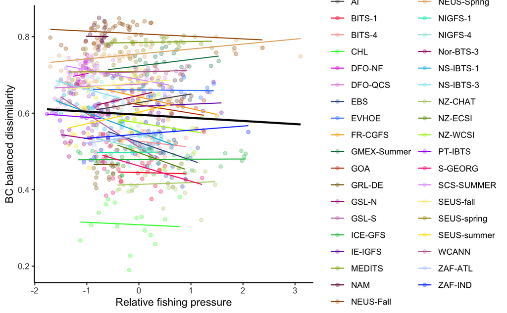

```r
#upper lower bounds from confidence intervals
dissimilarities_temp_fishing_regstats.na[,pred_summed_tonnes_scaled_byreg_lwr := fishing_confit[5,1] + fishing_confit[6,1]*summed_tonnes_scaled_byreg]#lower confidence interval
dissimilarities_temp_fishing_regstats.na[,pred_summed_tonnes_scaled_byreg_upr := fishing_confit[5,2] + fishing_confit[6,2]*summed_tonnes_scaled_byreg]#upper confidence interval


#for all regions
(allreg_BC_balanced_dissimilarity_fishing_mean <- ggplot(data = dissimilarities_temp_fishing_regstats.na) +
  labs(x = "Relative fishing pressure",  y = "BC balanced dissimilarity") +
  geom_point(aes(x = summed_tonnes_scaled_byreg, y = bray_curtis_dissimilarity_balanced_mean, color = survey_unit), alpha = 0.3) +
  geom_line(aes(x = summed_tonnes_scaled_byreg, y = pred_summed_tonnes_scaled_byreg_individual, color = survey_unit)) +
  geom_line(aes(x = summed_tonnes_scaled_byreg, y = pred_summed_tonnes_scaled_byreg), lwd = 1) +
  scale_color_manual(values =  pal_37) +
  theme_classic())

#save
ggsave(allreg_BC_balanced_dissimilarity_fishing_mean, path = here::here("figures","predictor_variables"), filename = "allreg_BC_balanced_dissimilarity_fishing_mean.jpg")
```

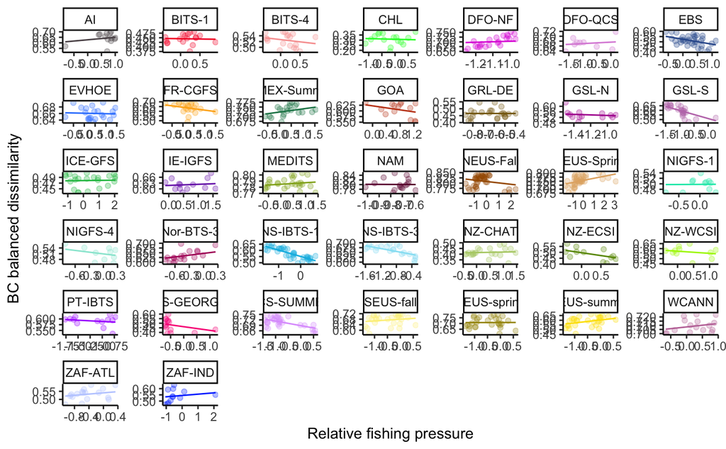

```r
#for all regions faceted
(allreg_BC_balanced_dissimilarity_fishing_mean_facet <- ggplot(data = dissimilarities_temp_fishing_regstats.na) +
  labs(x = "Relative fishing pressure",  y = "BC balanced dissimilarity") +
  geom_point(aes(x = summed_tonnes_scaled_byreg, y = bray_curtis_dissimilarity_balanced_mean, color = survey_unit), alpha = 0.3) +
  geom_line(aes(x = summed_tonnes_scaled_byreg, y = pred_summed_tonnes_scaled_byreg_individual, color = survey_unit)) +
  scale_color_manual(values =  pal_37) +
  facet_wrap(~survey_unit, scales = "free") +
  theme_classic() +
    theme(legend.position = "null"))

#save
ggsave(allreg_BC_balanced_dissimilarity_fishing_mean_facet, path = here::here("figures","predictor_variables"), filename = "allreg_BC_balanced_dissimilarity_fishing_mean_facet.jpg", height = 8, width = 12, unit = "in")
```

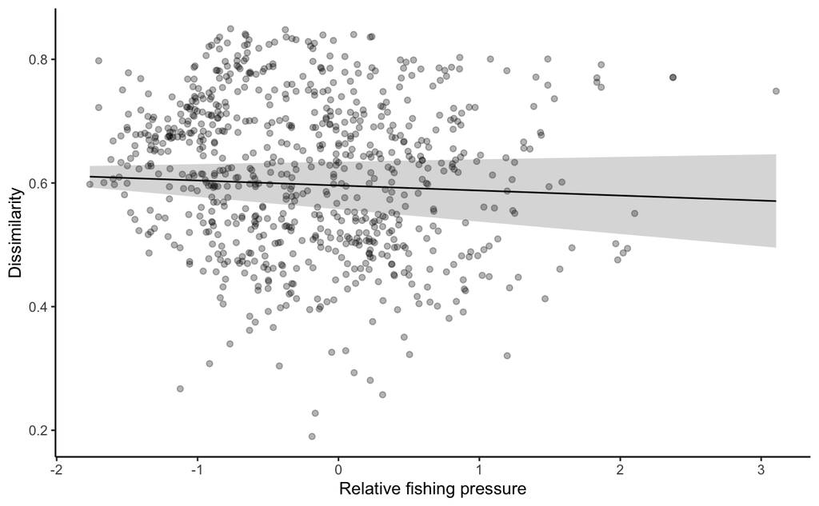

```r
#all one color points
(allreg_BC_balanced_dissimilarity_fishing_mean_SIMPLIFIED <- ggplot(data = dissimilarities_temp_fishing_regstats.na) +
  labs(x = "Relative fishing pressure",  y = "Dissimilarity") +
  geom_point(aes(x = summed_tonnes_scaled_byreg, y = bray_curtis_dissimilarity_balanced_mean), alpha = 0.3) +
  geom_line(aes(x = summed_tonnes_scaled_byreg, y = pred_summed_tonnes_scaled_byreg)) +
  geom_ribbon(aes(x = summed_tonnes_scaled_byreg, ymin = pred_summed_tonnes_scaled_byreg_lwr, ymax = pred_summed_tonnes_scaled_byreg_upr), alpha = 0.2) +
  theme_classic())

#save
ggsave(allreg_BC_balanced_dissimilarity_fishing_mean_SIMPLIFIED, path = here::here("figures","predictor_variables"), filename = "allreg_BC_balanced_dissimilarity_fishing_mean_SIMPLIFIED.jpg")
```

###Temperature x fishing models Best temp variables to carry forward:

For raw temp (indicative of survey vs. survey): -dissimilarity_BC_balanced_sst_mean_mod

For scaled temp (indicative of within survey: cool or warm year? heterogenous or homogenous year) -dissimilarity_BC_balanced_sst_mean_scaled_mod

Starting with survey unit as random effect again

```r
summary(allreg_dissimilarity_mod_sst_mean_avg)
```

```
Linear mixed model fit by REML. t-tests use Satterthwaite's method ['lmerModLmerTest']
Formula: bray_curtis_dissimilarity_balanced_mean ~ yearly_mean_bypoint_avg +      (1 | survey_unit)
   Data: dissimilarities_temp_fishing_regstats

REML criterion at convergence: -2714.7

Scaled residuals:
    Min      1Q  Median      3Q     Max
-3.9546 -0.5610  0.0518  0.5943  3.0596

Random effects:
 Groups      Name        Variance Std.Dev.
 survey_unit (Intercept) 0.01216  0.11026
 Residual                0.00142  0.03768
Number of obs: 785, groups:  survey_unit, 37

Fixed effects:
                         Estimate Std. Error        df t value Pr(>|t|)
(Intercept)             5.654e-01  3.247e-02 7.457e+01  17.414   <2e-16 ***
yearly_mean_bypoint_avg 2.645e-03  2.119e-03 1.221e+02   1.248    0.214
---
Signif. codes:  0 ‘***’ 0.001 ‘**’ 0.01 ‘*’ 0.05 ‘.’ 0.1 ‘ ’ 1

Correlation of Fixed Effects:
            (Intr)
yrly_mn_by_ -0.828
```

Fixed effects: Estimate Std. Error df t value Pr(>|t|)  
(Intercept) 5.654e-01 3.247e-02 7.457e+01 17.414 <2e-16 *** yearly_mean_bypoint_avg 2.645e-03 2.119e-03 1.221e+02 1.248 0.214

What about r^2 value

```r
r.squaredGLMM(allreg_dissimilarity_mod_sst_mean_avg)
```

```
            R2m       R2c
[1,] 0.02138025 0.8976474
```

#CODE BELOW MAY NO LONGER BE RELEVANT Plot this model with interaction

```r
library(interactions)
sim_slopes(allreg_dissimilarity_fishing_temp_mod_SDonly, pred = sst_SD_scaled, modx = summed_tonnes_scaled, johnson_neyman = FALSE)

interact_plot(allreg_dissimilarity_fishing_mean_mod_sst_max_avg, pred = yearly_max_bypoint_avg, modx = summed_tonnes_scaled_byreg, plot.points = T, colors = c("#b3ffe4","#00d68b","#003d28"), x.label = "Maximum Sea Surface Temperature", y.label = "Mean Annual Bray Curtis Dissimilarity") + theme_classic()

ggsave(filename = "interaction_fish_temp.png" ,height = 4, width = 10)

interact_plot(allreg_dissimilarity_fishing_temp_mod_SDonly, pred = sst_SD_scaled, modx = summed_tonnes_scaled, linearity.check = TRUE,
              plot.points = TRUE) #check linearity
```

###What if we also tie in latitude and spp num?

```r
allreg_dissimilarity_fishing_mean_mod_sst_max_avg_spp_num <- lmer(bray_curtis_dissimilarity_balanced_mean ~ summed_tonnes_scaled_byreg*yearly_max_bypoint_avg*spp_num.s + (1|survey_unit), data = dissimilarities_temp_fishing_regstats)

allreg_dissimilarity_fishing_mean_mod_sst_max_avg_mid_lat <- lmer(bray_curtis_dissimilarity_balanced_mean ~ summed_tonnes_scaled_byreg*yearly_max_bypoint_avg*mid_lat + (1|survey_unit), data = dissimilarities_temp_fishing_regstats)

allreg_dissimilarity_fishing_mean_mod_sst_max_avg_mid_lat_spp_num <- lmer(bray_curtis_dissimilarity_balanced_mean ~ summed_tonnes_scaled_byreg*yearly_max_bypoint_avg*mid_lat*spp_num.s + (1|survey_unit), data = dissimilarities_temp_fishing_regstats)

AIC(allreg_dissimilarity_fishing_mean_mod_sst_max_avg_spp_num, allreg_dissimilarity_fishing_mean_mod_sst_max_avg_mid_lat,allreg_dissimilarity_fishing_mean_mod_sst_max_avg_mid_lat_spp_num)

summary(allreg_dissimilarity_fishing_mean_mod_sst_max_avg_spp_num)
r.squaredGLMM(allreg_dissimilarity_fishing_mean_mod_sst_max_avg_spp_num)

#no interaction with spp num?
allreg_dissimilarity_fishing_mean_mod_sst_max_avg_spp_num_nointeract <- lmer(bray_curtis_dissimilarity_balanced_mean ~ summed_tonnes_scaled_byreg*yearly_max_bypoint_avg+spp_num.s + (1|survey_unit), data = dissimilarities_temp_fishing_regstats)

#exclude temperature?
allreg_dissimilarity_fishing_mean_mod_spp_num <- lmer(bray_curtis_dissimilarity_balanced_mean ~ summed_tonnes_scaled_byreg*spp_num.s + (1|survey_unit), data = dissimilarities_temp_fishing_regstats)

#exclude temp no interactions
allreg_dissimilarity_fishing_mean_mod_spp_num_nointeract <- lmer(bray_curtis_dissimilarity_balanced_mean ~ summed_tonnes_scaled_byreg+spp_num.s + (1|survey_unit), data = dissimilarities_temp_fishing_regstats)

AICc(allreg_dissimilarity_fishing_mean_mod_sst_max_avg_spp_num_nointeract,allreg_dissimilarity_fishing_mean_mod_spp_num, allreg_dissimilarity_fishing_mean_mod_sst_max_avg_spp_num,allreg_dissimilarity_fishing_mean_mod_spp_num_nointeract)

summary(allreg_dissimilarity_fishing_mean_mod_sst_max_avg_spp_num_nointeract)
r.squaredGLMM(allreg_dissimilarity_fishing_mean_mod_sst_max_avg_spp_num_nointeract)

#no temp performs better
summary(allreg_dissimilarity_fishing_mean_mod_spp_num_nointeract)
r.squaredGLMM(allreg_dissimilarity_fishing_mean_mod_spp_num_nointeract)

ggplot(dissimilarities_temp_fishing_regstats) +
  geom_point(aes(x = spp_num, y = bray_curtis_dissimilarity_balanced_mean, color = yearly_max_bypoint_avg)) +
  theme_classic()

ggplot(dissimilarities_temp_fishing_regstats) +
  geom_point(aes(x = yearly_max_bypoint_avg, y = bray_curtis_dissimilarity_balanced_mean, color = yearly_max_bypoint_avg)) +
  geom_smooth(aes(x = yearly_max_bypoint_avg, y = bray_curtis_dissimilarity_balanced_mean)) +
  theme_classic()
```